# Final Project

Margaret Rettig

4/13/2022

Load Necessary Libraries (will update as needed)

```r
library(readr)
library(XML)
```

For this project, the infant mortality data is stored in an XML file and the longitude and latitude data is stored in a csv file. The population data is also stored in a csv file.

This program reads these files, and then creates a graphical mapping of the data from this file. This graphical representation uses different sized circle to represent the size of the population and colors the circles based on the of infant mortality per 1000 live births.

Read the Longitude/Latitude Data

```r
latlonDF <- read_csv("long_lat_data.csv") #reads the data file of country names and locations
print(latlonDF) #prints the data file to ensure it makes sense
```

```
## # A tibble: 256 × 6
##    Country         `Alpha-2 code` `Alpha-3 code` `Numeric code` `Latitude (ave…`
##    <chr>           <chr>          <chr>                   <dbl>            <dbl>
##  1 Afghanistan     AF             AFG                         4             33
##  2 Albania         AL             ALB                         8             41
##  3 Algeria         DZ             DZA                        12             28
##  4 American Samoa  AS             ASM                        16            -14.3
##  5 Andorra         AD             AND                        20             42.5
##  6 Angola          AO             AGO                        24            -12.5
##  7 Anguilla        AI             AIA                       660             18.2
##  8 Antarctica      AQ             ATA                        10            -90
##  9 Antigua and Ba… AG             ATG                        28             17.0
## 10 Argentina       AR             ARG                        32            -34
## # … with 246 more rows, and 1 more variable: `Longitude (average)` <dbl>
```

```r
population <- read_csv("population.csv") #read population data
```

Locate the statistics in the XML file

```r
library(XML) #adds the package needed to read the XML file
factbookDoc = xmlParse("factbook.xml") #reads the information out of the XML file into R as a variable (external pointer)
factbookRoot = xmlRoot(factbookDoc) #finds the top level data labels in the XML file
xmlName(factbookRoot) #
```

```
## [1] "factbook"
```

```r
xmlSize(factbookRoot) #
```

```
## [1] 282
```

```r
table(names(factbookRoot)) #prints the labels of the top level data
```

```
##
##    appendix    category  definition faqCategory        news      region
##           7          10          44           7         201          13
```

```r
sapply(factbookRoot["category"], function(node) table(names(node))) #returns a vector of the category values
```

```
##             category category category category category category category
## description        1        1        1        1        1        1        1
## field              2       21       39       27       42       23        8
##             category category category
## description        1        1        1
## field             11        7        4
```

```r
sapply(factbookRoot["category"], xmlAttrs) #returns attributes of the XML file
```

```
##          category.name          category.name          category.name
##         "Introduction"            "Geography"   "People and Society"
##          category.name          category.name          category.name
##           "Government"              "Economy"               "Energy"
##          category.name          category.name          category.name
##       "Communications"       "Transportation"             "Military"
##          category.name
## "Transnational Issues"
```

```r
categoryNodes = factbookRoot["category"] #returns the categories of the Nodes
w = sapply(categoryNodes, xmlGetAttr, "name")=="People and Society" #finds the category titled people and society
Ids = sapply(categoryNodes[[which(w)]] ["field"], xmlGetAttr, "id") #gets the numerical id/index of the node with the infant mortality data
f2091Index = which(Ids == "f2091") #sorts the nodes by ids
f2091Index
```

```
## field
##    18
```

```r
rankNodes = categoryNodes[[which(w)]]["field"][[f2091Index]]["rank"] #finds the node category of the node with f2091 Index
xmlSize(rankNodes) #prints rankNodes
```

```
## [1] 224
```

Read the previously located Statistics out of the XML file

```r
infMortNum = sapply(rankNodes, xmlGetAttr, "number") #reads the infant mortality per 1000 live births into the variable infMortNum
infMortCtry = sapply(rankNodes, xmlGetAttr, "country") #reads the country corresponding to the infant mortaltiy data into the variable infMortCtry
head(infMortNum) #prints the first 6 values fo infMortNum
```

```
##     rank     rank     rank     rank     rank     rank
## "117.23" "104.34" "100.14"  "92.86"  "90.92"  "90.30"
```

```r
head(infMortCtry) #prints the first 6 values for infMortCtry
```

```
## rank rank rank rank rank rank
## "af" "ml" "so" "ct" "pu" "cd"
```

Double Check that we have the correct node/statistics This section prints out the qualities of the node that the staistics were read from

```r
x = c(x= "file:///Users/rettigm/Downloads/factbook.xml")
field2091 = getNodeSet(factbookDoc, "//field[@id = 'f2091']", namespaces = xmlNamespaceDefinitions(factbookDoc, simplify = TRUE))
xmlAttrs(field2091[[1]])
```

```
##                      dollars                         unit
##                      "false" "(deaths/1,000 live births)"
##                    rankorder                         name
##                          "1"      "Infant mortality rate"
##                           id
##                      "f2091"
```

Examine Attribute Values of the 1st Node

```r
rankNodes = getNodeSet(factbookDoc, "//field[@id='f2091']/rank")
xmlAttrs(rankNodes[[1]])
```

```
##        number dateEstimated    dateLatest  dateEarliest      dateText
##      "117.23"        "true"  "2014-12-31"  "2014-01-01"   "2014 est."
##       country
##          "af"
```

Extract attributes and values from these nodes

```r
infNum = as.numeric(sapply(rankNodes, xmlGetAttr, "number"))
infCtry = sapply(rankNodes, xmlGetAttr, "country")
```

Write this information into a data frame

```r
infMortDF = data.frame(infMort = infNum, ctry = infCtry, stringsAsFactors = FALSE)
rankNodes = getNodeSet(factbookRoot, "//field[@id='f2119']/rank")
popNum = as.numeric(sapply(rankNodes, xmlGetAttr, "number"))
popCtry = sapply(rankNodes, xmlGetAttr, "country")
popDF = data.frame(pop = popNum, ctry = popCtry, stringsAsFactors = FALSE)
```

Read in CSV Files for infant mortality rate to make sure the countries are correct

```r
library(readr)
country_comparison_infant_mortality_rate <- read_csv("country_comparison_infant_mortality_rate.csv")
country_codes <- read_csv("country-codes.csv")
```

Examine data sets

```r
head(latlonDF)
```

```
## # A tibble: 6 × 6
##   Country        `Alpha-2 code` `Alpha-3 code` `Numeric code` `Latitude (avera…`
##   <chr>          <chr>          <chr>                   <dbl>              <dbl>
## 1 Afghanistan    AF             AFG                         4               33
## 2 Albania        AL             ALB                         8               41
## 3 Algeria        DZ             DZA                        12               28
## 4 American Samoa AS             ASM                        16              -14.3
## 5 Andorra        AD             AND                        20               42.5
## 6 Angola         AO             AGO                        24              -12.5
## # … with 1 more variable: `Longitude (average)` <dbl>
```

```r
head(popDF)
```

```
##          pop ctry
## 1 1355692576   ch
## 2 1236344631   in
## 3  511434812   ee
## 4  318892103   us
## 5  253609643   id
## 6  202656788   br
```

```r
head(infMortDF)
```

```
##   infMort ctry
## 1  117.23   af
## 2  104.34   ml
## 3  100.14   so
## 4   92.86   ct
## 5   90.92   pu
## 6   90.30   cd
```

Merge the data frames into 1

```r
IMPop = merge(infMortDF, popDF, by = "ctry", all = FALSE) #merge the infant mortality and population data frames
dim(IMPop)
```

```
## [1] 224   3
```

```r
latlonDF$code = tolower(as.character(latlonDF$`Alpha-2 code`)) #convert codes to lowercase to be able to match them

newlatlonDF = merge(country_comparison_infant_mortality_rate, latlonDF, by.x = "country", by.y = "Country") #merge infant mortality data and latitude longitude data
allCtryData = merge(newlatlonDF, population, by.x = "country", by.y = "Name")
```

Access and select a color pallet, and summarize the data, then create a histogram of the data

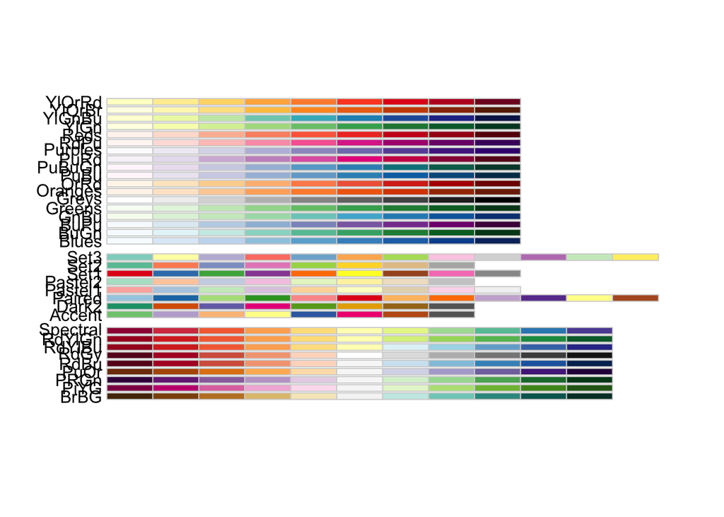

```r
library(RColorBrewer)
display.brewer.all()
```

```r
cols = brewer.pal(9, "YlOrRd")[c(1, 2, 4, 6, 7)]

newInfMort = cut(allCtryData$amount, breaks = 5)
summary(newInfMort)
```

```
##  (1.6,22.2] (22.2,42.7] (42.7,63.3] (63.3,83.8]  (83.8,104]
##         108          32          14           4           2
```

```r
newInfMort2 = cut(allCtryData$amount, breaks = c(0, 37, 50, 65, 80, 150))
summary(newInfMort2)
```

```
##   (0,37]  (37,50]  (50,65]  (65,80] (80,150]
##      131       14       11        2        2
```

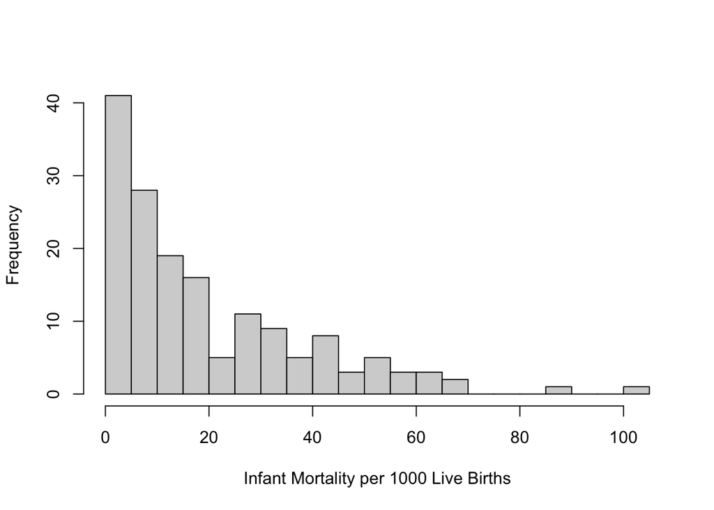

```r
hist(allCtryData$amount, breaks = 20, main = "", xlab = "Infant Mortality per 1000 Live Births")
```

```r
quantile(allCtryData$amount, probs = seq(0, 1, by = 0.2))
```

```
##     0%    20%    40%    60%    80%   100%
##   1.70   4.12   9.22  17.04  32.28 104.30
```

```r
InfMortDiscrete = cut(allCtryData$amount, breaks = c(0, 10, 25, 50, 75, 150))

popDiscrete = cut(allCtryData$Value, breaks = c(0,10,25,50,75,150))
```

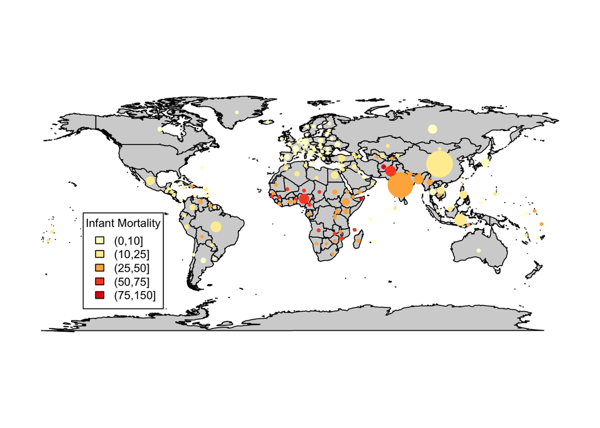

```r
library(maps)
world = map(database = "world", fill = TRUE, col="light grey") #create a world map
rads = pmax(sqrt(allCtryData$Value)/4000, 1) #create a variable to size and scale the circles
symbols(allCtryData$`Longitude (average)`, allCtryData$`Latitude (average)`, add = TRUE, circles= rads, inches = FALSE, fg = cols[InfMortDiscrete], bg = cols[InfMortDiscrete])
#use the symbols() command to add the circles to the map
legend(x = -150, y = 0, title = "Infant Mortality",legend = levels(InfMortDiscrete), fill = cols, cex = 0.8) #add a legend to the map for easier understanding
```